[video not shown]

# Portfolio

**Welcome** to my portfolio, where passion and innovation come together to create impactful projects. From AI-powered customer service systems to scalable architectures, each endeavor represents my commitment to excellence. Join me on this exciting journey as we explore the possibilities and pave the way for a future where technology and human ingenuity thrive.

[figure not shown]

Home |

- Article

# Comparing and Profiling 5 Versions of Flood-Fill Algorithms

## A Comparative Study

### ASCII Paint Bucket's Problem

Imagine that we have friend that is developing a small image processing program and has asked for your help in implementing MS-Paint's “paint bucket”-like functionality.

Their program represents images using arrays of characters, with each array value representing a pixel and letters and symbols representing different colors.

For example, the following 4x6 matrix represents the letter P in color "`#`", with background color "`.`" (dot)

`.###..`  
`.#..#.`  
`.###..`  
`.#....`

Your subroutine should:

1. take a pixel and a new color
2. and paint the region of that pixel with the new color,

like MS-Paint's “paint bucket” tool.

#### Examples:

Let's consider the following examples to demonstrate the Fill Flood algorithm implementation:

**1. Starting pixel: (0, 1) with new color 'O'**

*Before*  
`.###..`  
`.#..#.`  
`.###..`  
`.#....`

*After applying the Fill Flood algorithm:*  
`.OOO..`  
`.O..#.`  
`.OOO..`  
`.O....`

**2. Starting pixel: (1, 3) with new color 'o'**

*Before*  
`.###..`  
`.#..#.`  
`.###..`  
`.#....`

*After applying the Fill Flood algorithm:*  
`.###..`  
`.#oo#.`  
`.###..`  
`.#....`

**2. Starting pixel: (1, 3) with new color '#'**

*Before*  
`.###..`  
`.#..#.`  
`.###..`  
`.#....`

*After applying the Fill Flood algorithm:*  
`.###..`  
`.####.`  
`.###..`  
`.#....`

### First Solution

We can using DFS with recursion as below:

```python
def flood_fill_dfs(image_grid, x, y, new_color):
    rows, cols = len(image_grid), len(image_grid[0])
    old_color = image_grid[x][y]

    def dfs(x, y):
        if x < 0 or x >= rows or y < 0 or y >= cols:
            return
        if image_grid[x][y] != old_color:
            return
        image_grid[x][y] = new_color

        dfs(x + 1, y)
        dfs(x - 1, y)
        dfs(x, y + 1)
        dfs(x, y - 1)

    dfs(x, y)

    return image_grid
```

Although this option covers all the test cases passed in this problem as shown below:

```python
import ipytest
ipytest.autoconfig()
ipytest.config(rewrite_asserts=False)
```

```
{'rewrite_asserts': False,
 'magics': True,
 'clean': '[Tt]est*',
 'addopts': ('-q', '--color=yes'),
 'run_in_thread': False,
 'defopts': 'auto',
 'display_columns': 100,
 'raise_on_error': False}
```

```python
%%ipytest -qq

def test_cases_paint_bucket():
    image1 = [list(".###.."), list(".#..#."), list(".###.."), list(".#....")]
    expected1 = [list(".OOO.."), list(".O..#."), list(".OOO.."), list(".O....")]
    flood_fill_dfs(image1, 0, 1, 'O')
    assert image1 == expected1

    image2 = [list(".###.."), list(".#..#."), list(".###.."), list(".#....")]
    expected2 = [list(".###.."), list(".#oo#."), list(".###.."), list(".#....")]
    flood_fill_dfs(image2, 1, 3, 'o')
    assert image2 == expected2

    image3 = [list(".###.."), list(".#..#."), list(".###.."), list(".#....")]
    expected3 = [list(".###.."), list(".####."), list(".###.."), list(".#....")]
    flood_fill_dfs(image3, 1, 3, '#')
    assert image3 == expected3
```

```
.                                                                                            [100%]
```

It will easily take a recursion with a larger grid and will eventually generate:

`RecursionError: maximum recursion depth exceeded in comparison`

```python
import sys
recursion_limit = sys.getrecursionlimit()
print(recursion_limit)
```

```
3000
```

Since in the python 3.10 version I'm using the 3000 depth limit.

### Other solutions using: Optimized Depth-First Search and Breadth-First Search

Taking a step back, the first thing we have to deal with is the best-case scenario `O(1)`, if the pixel's `old_color` is equal `new_color` does nothing and the function returns.

```python
def flood_fill(grid, x, y, new_color):
    old_color = grid[x][y]
    if new_color == old_color:
        return grid
```

```python
%%ipytest -qq

def test_best_case_scenario():
    image1 = [list(".###.."), list(".#..#."), list(".###.."), list(".#....")]
    expected1 = [list(".###.."), list(".#..#."), list(".###.."), list(".#....")]
    flood_fill(image1, 0, 1, '#')
    assert image1 == expected1
```

```
.                                                                                            [100%]
```

Of course this solves only the happiest case, and to solve the other cases we will use two options of graph traversal algorithms:

- Depth-First Search (DFS)
- Breadth-First Search (BFS)

So for simplicity our first function will receive an additional argument called `gt_algorithm` which is a function that will be called internally:

```python
def flood_fill(grid, x, y, new_color, gt_algorithm):
    old_color = grid[x][y]
    if new_color == old_color:
        return
    gt_algorithm(grid, x, y, old_color, new_color)
```

Now let's go to our options for flood fill functions without RecursionError.

Before for test title let's use this unconventional test function below:

```python
import copy
initial_image = [list(".###.."), list(".#..#."), list(".###.."), list(".#....")]

def test_cases_paint_bucket(gt_algorithm):
    image1 = copy.deepcopy(initial_image)
    expected1 = [list(".OOO.."), list(".O..#."), list(".OOO.."), list(".O....")]
    flood_fill(image1, 0, 1, 'O', gt_algorithm)
    assert image1 == expected1

    image2 = copy.deepcopy(initial_image)
    expected2 = [list(".###.."), list(".#oo#."), list(".###.."), list(".#....")]
    flood_fill(image2, 1, 3, 'o', gt_algorithm)
    assert image2 == expected2

    image3 = copy.deepcopy(initial_image)
    expected3 = [list(".###.."), list(".####."), list(".###.."), list(".#....")]
    flood_fill(image3, 1, 3, '#', gt_algorithm)
    assert image3 == expected3

    return True
```

#### Using Depth-First Search option with stack to avoid recursion and stack overflow errors

##### DFS with stack

To avoid the recursion error we can implement dfs using a list as a stack (LIFO)

```python
# Function using depth-first search (DFS) using stack
def dfs_with_stack(grid, x, y, old_color, new_color):
    rows, cols = len(grid), len(grid[0])
    stack = [(x, y)]
    while stack:
        # LIFO
        x, y = stack.pop()
        if 0 <= x < rows and 0 <= y < cols\
                and grid[x][y] == old_color:
            grid[x][y] = new_color
            stack.extend([
                (x + 1, y),
                (x - 1, y),
                (x, y + 1),
                (x, y - 1)])

    return grid
```

Checking if it passes the tests:

```python
test_cases_paint_bucket(dfs_with_stack)
```

```
True
```

##### Using list as queue

Similarly we can use implement a bfs using a list like queue(FIFO)

```python
# Function using breadth-first search (BFS) using list queue
def bfs_with_list_as_queue(grid, x, y, old_color, new_color):
    rows, cols = len(grid), len(grid[0])

    queue = [(x, y)]
    while queue:
        # FIFO
        x, y = queue.pop(0)
        if 0 <= x < rows and 0 <= y < cols \
                and grid[x][y] == old_color:
            grid[x][y] = new_color
            queue.extend([
                (x + 1, y),
                (x - 1, y),
                (x, y + 1),
                (x, y - 1)])
    return grid
```

Checking if it still passing the tests:

```python
test_cases_paint_bucket(bfs_with_list_as_queue)
```

```
True
```

##### Using deque no instead of list

But for performance terms it is better to use what as queue (FIFO)

```python
from collections import deque

# Function using breadth-first search (BFS) using deque as queue
def bfs_with_deque_as_queue(grid, x, y, old_color, new_color):
    rows, cols = len(grid), len(grid[0])

    queue = deque([(x, y)])
    while queue:
        x, y = queue.popleft()
        if 0 <= x < rows and 0 <= y < cols \
                and grid[x][y] == old_color:
            grid[x][y] = new_color
            queue.extend([
                (x + 1, y),
                (x - 1, y),
                (x, y + 1),
                (x, y - 1)])

    return grid
```

Checking the test cases:

```python
test_cases_paint_bucket(bfs_with_deque_as_queue)
```

```
True
```

#### Aditional - DFS stack with labeling

additionally we can use marking the already visited pixels

##### Using set for labeling

```python
# Function using depth-first search (DFS) using stack
def dfs_with_stack_label(grid, x, y, old_color, new_color):
    rows, cols = len(grid), len(grid[0])
    stack = [(x, y)]
    visited = set()

    while stack:
        # LIFO
        x, y = stack.pop()
        if 0 <= x < rows and 0 <= y < cols\
                and grid[x][y] == old_color:
            visited.add((x, y))
            grid[x][y] = new_color
            stack.extend([
                (x + 1, y),
                (x - 1, y),
                (x, y + 1),
                (x, y - 1)])

    return grid
```

```python
test_cases_paint_bucket(dfs_with_stack_label)
```

```
True
```

##### Using a matrix for labeling

```python
# Function using depth-first search (DFS) using stack
def dfs_with_stack_with_matrix_selected(grid, x, y, old_color, new_color):
    rows, cols = len(grid), len(grid[0])
    stack = [(x, y)]
    visited = [[False]*cols for _ in range(rows)]

    while stack:
        # LIFO
        x, y = stack.pop()
        if 0 <= x < rows and 0 <= y < cols\
                and grid[x][y] == old_color:
            visited[x][y] = True
            grid[x][y] = new_color
            stack.extend([
                (x + 1, y),
                (x - 1, y),
                (x, y + 1),
                (x, y - 1)])

    return grid
```

```python
test_cases_paint_bucket(dfs_with_stack_with_matrix_selected)
```

```
True
```

All implemented functions above:

- dfs_with_stack
- bfs_with_list_as_queue
- bfs_with_deque_as_queue
- dfs_with_stack_label
- dfs_with_stack_with_matrix_selected

have a time complexity of O(m * n), where m is the number of rows and n is the number of columns in the grid.

**Despite this, we can ask which one would be the most performative?**

Before Before answering that, I gave myself the luxury of taking a profiling test.

```python
def generate_image_grid(grid_size):
    return [list('#' * grid_size) for _ in range(grid_size)]
```

This function above generates a grid of images represented by '#' symbols. The size of the grid is determined by the parameter 'grid_size'. We are going to use it in our profiling

### Performance profiling

```python
import timeit
import copy

increases = []
execution_times_1 = []
execution_times_2 = []
execution_times_3 = []
execution_times_4 = []
execution_times_5 = []

def time_func(img_grid, gt_algorithm):
    copy_img_grid = copy.deepcopy(img_grid)
    return timeit.timeit(
            lambda: flood_fill(
                copy_img_grid,
                0, 1, 'O',
                gt_algorithm
        ), number=100)

def f(x):
    return 10*x

for x in range(1, 50):
    increase = f(x)
    increases.append(increase)
    img_grid = generate_image_grid(increase)

    execution_time_1 = time_func(img_grid, dfs_with_stack)
    execution_time_2 = time_func(img_grid, bfs_with_list_as_queue)
    execution_time_3 = time_func(img_grid, bfs_with_deque_as_queue)
    execution_time_4 = time_func(img_grid, dfs_with_stack_label)
    execution_time_5 = time_func(img_grid, dfs_with_stack_with_matrix_selected)

    execution_times_1.append(execution_time_1)
    execution_times_2.append(execution_time_2)
    execution_times_3.append(execution_time_3)
    execution_times_4.append(execution_time_4)
    execution_times_5.append(execution_time_5)
```

And plot it on the graph

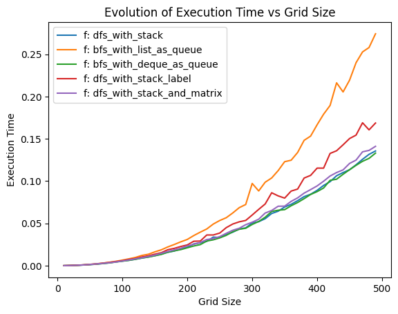

```python
import matplotlib.pyplot as plt
plt.plot(increases, execution_times_1, label='f: dfs_with_stack')
plt.plot(increases, execution_times_2, label='f: bfs_with_list_as_queue')
plt.plot(increases, execution_times_3, label='f: bfs_with_deque_as_queue')
plt.plot(increases, execution_times_4, label='f: dfs_with_stack_label')
plt.plot(increases, execution_times_5, label='f: dfs_with_stack_and_matrix')

plt.xlabel('Grid Size')
plt.ylabel('Execution Time')
plt.title('Evolution of Execution Time vs Grid Size')
plt.legend()
plt.show()
```

### Conclusion

As observed in the graph, the most performant functions were:

- `bfs_with_deque_as_queue`
- `dfs_with_stack`

Very close to these we have:

- `dfs_with_stack_and_matrix`

And the least performant of these options were:

- `dfs_with_stack_label`
- `bfs_with_list_as_queue`

Among the given functions, the one with the best performance in terms of time complexity would be `bfs_with_deque_as_queue` using a `deque` as a queue. This is because a `deque` provides efficient operations for adding elements to the end (`queue.extend`) and removing elements from the front (`queue.popleft`). These operations have a time complexity of `O(1)` on average.

Already in the functions `dfs_with_stack_label` and `dfs_with_stack_with_matrix_selected` which should be improved versions of `dfs_with_stack`. We can see that our labeling system that we intended to use, ended up bringing more cost than performance increase, as they only add additional operations to track visited cells.

So overall, using a deque as a queue in `bfs_with_deque_as_queue` provides the best performance among the given functions due to efficient removal of elements from the front, resulting in the best optimal timing complexity.

---

## Get in touch

If you have any questions or would like to engage in a conversation, I welcome you to reach out to me. Feel free to send me a message directly, and I'll be happy to connect with you.

Feel free to visit my LinkedIn profile at [@daviguides](https://www.linkedin.com/in/daviguides/) to connect and learn more about my professional journey.

You can also visit my GitHub profile at GitHub Profile: [@daviguides](https://github.com/daviguides)

I look forward to hearing from you and discussing exciting opportunities or answering any queries you may have.

---

## More About Me

I am a very curious and proactive professional with a great capacity to absorb new knowledge. I always seek to think creatively, practically, and systematically to achieve the most relevant results for the business. I always ask myself: What pain are we addressing here? How much value and differentiation will this add to the company? If the answer is positive, I try to understand which part of the whole will bring the greatest impact. Whether alone or in a group, it is a pleasure to accomplish and see things happen.

[figure not shown]

As a neurodivergent person with Giftedness, my hyperfocus and commitment are focused on continuous learning and improvement, respecting both my uncommon abilities, such as divergent deep thinking, whole-detail perspective, integration of opposing ideas and perspectives, among others, and the limitations of my condition, such as hyperesthesia and hypersensitivities, among others.

I thrive in projects that offer constant growth opportunities and challenges, particularly those with a data-driven, pragmatic, ethical, and pluralistic decision-making approach.

Pronouns: He/Him 🌈

Fun fact: I have a beautiful black cat who sometimes shows up to say hello in meetings or do some pair programming with me.

[figure not shown]

Other curiosities: once every 15 days, my friend Ana comes over and we do a home co-working session.

Also, once a month, Ana and I have a Spa Saturday, dedicated to being a day of relaxation, with meditation, QiGong and yoga practices, reiki, and more. It's important for us to reduce stress levels and keep our minds fresh and ready for action.

[figure not shown]